# Analysis of Inventory Generation Methods for Forest Simulation

Clémentine de Montgolfier

2025-09-09

# Abstract

This study tests different methods for generating initial forest inventories for the FORCEEPS simulation model. We compare the effects of various diameter distributions and species proportions on simulation outputs.

The initial data comes from the Retz forest, providing basal area, dominant diameter intervals, and species proportions rounded to 10%. This must be converted to a FORCEEPS inventory format for 1000 m² plots (max 3000 m²), raising several methodological questions:

- How to handle species representation when low percentages result in fractional trees (e.g., 2% beech in 20 trees = 0.4 trees)?
- Should we test variations around initial data given unknown uncertainties and their potential effects on forest dynamics?

This preliminary analysis explores these questions and provides a foundation for more comprehensive future research.

# Initial Inventory Analysis

```
## Checking for missing packages...
## All required packages are already installed.
```

```
## All libraries loaded successfully.
## ==============================================================================
```

**Figure 1: Basal area by species in initial inventories**

This analysis uses a single inventory from the Retz forest. Different functions were used to create the inventories:

- **Diameter distribution methods**: max, min, mean, normal_6, normal_4, unif (representing different statistical approaches to diameter allocation)
- **Species proportion methods**: fixe (fixed) or aléatoire (random) (representing deterministic vs. stochastic species allocation)

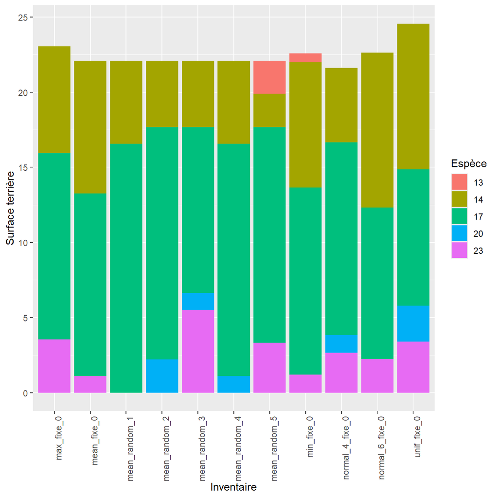